title: “Business Intelligence Lab Submission Markdown” author: “Acers Team” date: “11/10/2023”

# Student Details

**Student ID Numbers and Names of Group Members**

1. 122790 - C - Bwalley Nicholas
2. 133834 - C - Mongare Sarah
3. 133928 - C - Cheptoi Millicent
4. 134879 - C - Tulienge Lesley
5. 124461 - C - Kinya Angela

**GitHub Classroom Group Name**

Acers Team

**Course Code**

BBT4206

**Course Name**

Business Intelligence II

**Program**

Bachelor of Business Information Technology

**Semester Duration**

21<sup>st</sup> August 2023 to 28<sup>th</sup> November 2023

# Understanding the Dataset (Exploratory Data Analysis (EDA))

## STEP 1. Install and Load the Required Packages —-

```r
if (require("languageserver")) {
  require("languageserver")
} else {
  install.packages("languageserver", dependencies = TRUE,
                   repos = "https://cloud.r-project.org")
}
knitr::opts_chunk$set(echo = TRUE, warning = FALSE, eval = TRUE,
                      collapse = FALSE, tidy = TRUE, include=TRUE)
```

**Note:** the following “*R Markdown*” options have been set as the defaults:

> output:  
> github_document:  
> toc: yes  
> toc_depth: 4  
> fig_width: 6  
> fig_height: 4  
> df_print: default  
> editor_options:  
> chunk_output_type: console

# STEP 1 : Install and load all the packages

We installed all the packages that will enable us execute this lab:

```r
## mlbench ----
if (require("mlbench")) {
    require("mlbench")
} else {
    install.packages("mlbench", dependencies = TRUE, repos = "https://cloud.r-project.org")
}
## readr ----
if (require("readr")) {
    require("readr")
} else {
    install.packages("readr", dependencies = TRUE, repos = "https://cloud.r-project.org")
}
## caret ----
if (require("caret")) {
    require("caret")
} else {
    install.packages("caret", dependencies = TRUE, repos = "https://cloud.r-project.org")
}
## e1071 ----
if (require("e1071")) {
    require("e1071")
} else {
    install.packages("e1071", dependencies = TRUE, repos = "https://cloud.r-project.org")
}
## factoextra ----
if (require("factoextra")) {
    require("factoextra")
} else {
    install.packages("factoextra", dependencies = TRUE, repos = "https://cloud.r-project.org")
}
## FactoMineR ----
if (require("FactoMineR")) {
    require("FactoMineR")
} else {
    install.packages("FactoMineR", dependencies = TRUE, repos = "https://cloud.r-project.org")
}
```

## STEP 2: Loading datasets

```r
library(readr)


StudentPerformanceDataset <- read_csv("C:/Users/NICK BWALLEY/OneDrive - Strathmore University/MyStrath/BBIT/4.2/Business Intelligence II - Dr. Allan Omondi/BI2-Labs/BBT4206-R-Lab4of15-DataTransforms-acers_team/data/StudentPerformanceDataset.csv")
View(StudentPerformanceDataset)
```

## STEP 3. Apply a Scale Data Transform —-

```r
summary(StudentPerformanceDataset)
```

```
##  class_group            gender            YOB       regret_choosing_bi
##  Length:101         Min.   :0.0000   Min.   :1998   Min.   :0.0000
##  Class :character   1st Qu.:0.0000   1st Qu.:2000   1st Qu.:0.0000
##  Mode  :character   Median :1.0000   Median :2001   Median :0.0000
##                     Mean   :0.5743   Mean   :2001   Mean   :0.0198
##                     3rd Qu.:1.0000   3rd Qu.:2002   3rd Qu.:0.0000
##                     Max.   :1.0000   Max.   :2003   Max.   :1.0000
##
##   drop_bi_now       motivator      read_content_before_lecture
##  Min.   :0.0000   Min.   :0.0000   Min.   :1.000
##  1st Qu.:0.0000   1st Qu.:1.0000   1st Qu.:2.000
##  Median :0.0000   Median :1.0000   Median :3.000
##  Mean   :0.0198   Mean   :0.7525   Mean   :2.752
##  3rd Qu.:0.0000   3rd Qu.:1.0000   3rd Qu.:3.000
##  Max.   :1.0000   Max.   :1.0000   Max.   :5.000
##
##  anticipate_test_questions answer_rhetorical_questions find_terms_I_do_not_know
##  Min.   :1.000             Min.   :1.000               Min.   :1.000
##  1st Qu.:3.000             1st Qu.:3.000               1st Qu.:3.000
##  Median :4.000             Median :4.000               Median :4.000
##  Mean   :3.584             Mean   :3.426               Mean   :3.743
##  3rd Qu.:4.000             3rd Qu.:4.000               3rd Qu.:5.000
##  Max.   :5.000             Max.   :5.000               Max.   :5.000
##
##  copy_new_terms_in_reading_notebook take_quizzes_and_use_results
##  Min.   :1.000                      Min.   :1.000
##  1st Qu.:3.000                      1st Qu.:3.000
##  Median :4.000                      Median :4.000
##  Mean   :3.663                      Mean   :3.941
##  3rd Qu.:4.000                      3rd Qu.:5.000
##  Max.   :5.000                      Max.   :5.000
##
##  reorganise_course_outline write_down_important_points space_out_revision
##  Min.   :1.000             Min.   :1.000               Min.   :1.000
##  1st Qu.:3.000             1st Qu.:3.000               1st Qu.:3.000
##  Median :3.000             Median :4.000               Median :3.000
##  Mean   :3.376             Mean   :3.832               Mean   :3.228
##  3rd Qu.:4.000             3rd Qu.:5.000               3rd Qu.:4.000
##  Max.   :5.000             Max.   :5.000               Max.   :5.000
##
```

[output cut: 377 more lines]

```
##  Min.   : 7.47                Min.   : 5.00
##  1st Qu.:20.44                1st Qu.:26.00
##  Median :24.58                Median :34.00
##  Mean   :24.53                Mean   :33.94
##  3rd Qu.:29.31                3rd Qu.:42.00
##  Max.   :35.08                Max.   :56.00
##                               NA's   :4
##  TOTAL = Coursework TOTAL + EXAM (100%)    GRADE
##  Min.   : 7.47                          Length:101
##  1st Qu.:45.54                          Class :character
##  Median :58.69                          Mode  :character
##  Mean   :57.12
##  3rd Qu.:68.83
##  Max.   :87.72
##
```

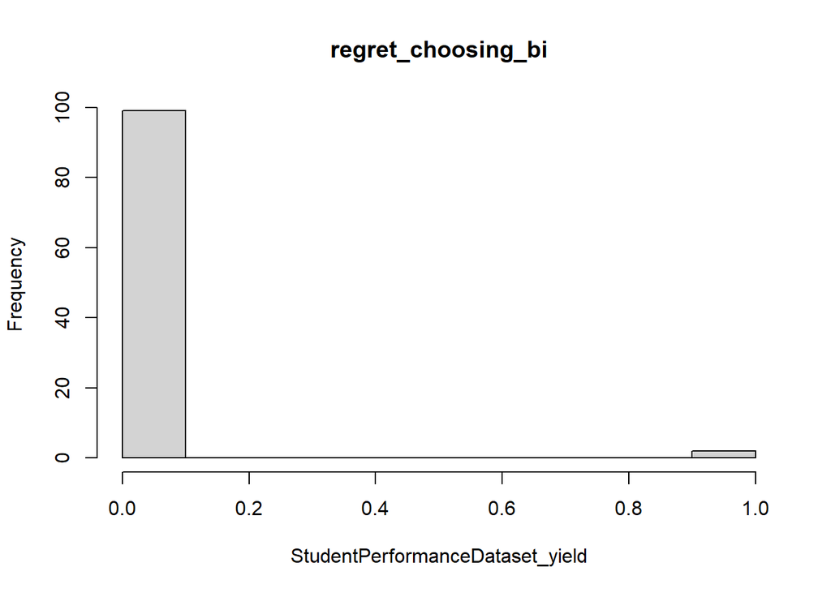

```r
# The code below converts column number 4 into unlisted and numeric data first
# so that a histogram can be plotted. Further reading:
StudentPerformanceDataset_yield <- as.numeric(unlist(StudentPerformanceDataset[,
    4]))
hist(StudentPerformanceDataset_yield, main = names(StudentPerformanceDataset)[4])
```

```r
model_of_the_transform <- preProcess(StudentPerformanceDataset, method = c("scale"))
print(model_of_the_transform)
```

```
## Created from 51 samples and 100 variables
##
## Pre-processing:
##   - ignored (4)
##   - scaled (96)
```

```r
student_dataset_scale_transform <- predict(model_of_the_transform, StudentPerformanceDataset)

# AFTER
summary(student_dataset_scale_transform)
```

```
##  class_group            gender           YOB       regret_choosing_bi
##  Length:101         Min.   :0.000   Min.   :2008   Min.   :0.0000
##  Class :character   1st Qu.:0.000   1st Qu.:2010   1st Qu.:0.0000
##  Mode  :character   Median :2.012   Median :2011   Median :0.0000
##                     Mean   :1.156   Mean   :2011   Mean   :0.1414
##                     3rd Qu.:2.012   3rd Qu.:2012   3rd Qu.:0.0000
##                     Max.   :2.012   Max.   :2013   Max.   :7.1421
##
##   drop_bi_now       motivator     read_content_before_lecture
##  Min.   :0.0000   Min.   :0.000   Min.   :1.038
##  1st Qu.:0.0000   1st Qu.:2.306   1st Qu.:2.076
##  Median :0.0000   Median :2.306   Median :3.114
##  Mean   :0.1414   Mean   :1.735   Mean   :2.857
##  3rd Qu.:0.0000   3rd Qu.:2.306   3rd Qu.:3.114
##  Max.   :7.1421   Max.   :2.306   Max.   :5.190
##
##  anticipate_test_questions answer_rhetorical_questions find_terms_I_do_not_know
##  Min.   :1.007             Min.   :1.007               Min.   :0.9478
##  1st Qu.:3.022             1st Qu.:3.020               1st Qu.:2.8435
##  Median :4.030             Median :4.026               Median :3.7914
##  Mean   :3.611             Mean   :3.448               Mean   :3.5474
##  3rd Qu.:4.030             3rd Qu.:4.026               3rd Qu.:4.7392
##  Max.   :5.037             Max.   :5.033               Max.   :4.7392
##
##  copy_new_terms_in_reading_notebook take_quizzes_and_use_results
##  Min.   :0.9033                     Min.   :0.9299
##  1st Qu.:2.7099                     1st Qu.:2.7897
##  Median :3.6132                     Median :3.7196
##  Mean   :3.3091                     Mean   :3.6644
##  3rd Qu.:3.6132                     3rd Qu.:4.6495
##  Max.   :4.5165                     Max.   :4.6495
##
##  reorganise_course_outline write_down_important_points space_out_revision
##  Min.   :0.8648            Min.   :0.9279              Min.   :0.8847
##  1st Qu.:2.5945            1st Qu.:2.7838              1st Qu.:2.6541
##  Median :2.5945            Median :3.7117              Median :2.6541
##  Mean   :2.9199            Mean   :3.5555              Mean   :2.8556
##  3rd Qu.:3.4593            3rd Qu.:4.6396              3rd Qu.:3.5388
##  Max.   :4.3241            Max.   :4.6396              Max.   :4.4235
##
```

[output cut: 377 more lines]

```
##  Min.   :1.200                Min.   :0.4441
##  1st Qu.:3.284                1st Qu.:2.3094
##  Median :3.949                Median :3.0200
##  Mean   :3.941                Mean   :3.0145
##  3rd Qu.:4.709                3rd Qu.:3.7306
##  Max.   :5.636                Max.   :4.9742
##                               NA's   :4
##  TOTAL = Coursework TOTAL + EXAM (100%)    GRADE
##  Min.   :0.475                          Length:101
##  1st Qu.:2.896                          Class :character
##  Median :3.732                          Mode  :character
##  Mean   :3.632
##  3rd Qu.:4.377
##  Max.   :5.578
##
```

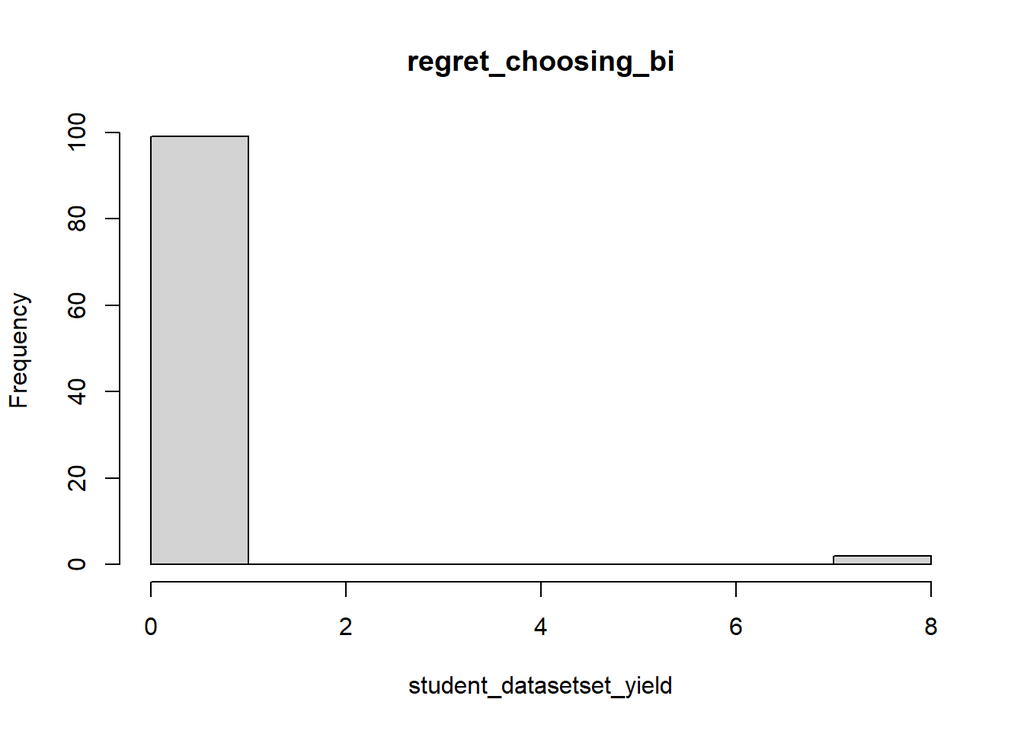

```r
student_datasetset_yield <- as.numeric(unlist(student_dataset_scale_transform[, 4]))
hist(student_datasetset_yield, main = names(student_dataset_scale_transform)[4])
```

## STEP 4. Apply a Centre Data Transform —-

```r
### The Centre Basic Transform on the StudentDataset ----
summary(StudentPerformanceDataset)
```

```
##  class_group            gender            YOB       regret_choosing_bi
##  Length:101         Min.   :0.0000   Min.   :1998   Min.   :0.0000
##  Class :character   1st Qu.:0.0000   1st Qu.:2000   1st Qu.:0.0000
##  Mode  :character   Median :1.0000   Median :2001   Median :0.0000
##                     Mean   :0.5743   Mean   :2001   Mean   :0.0198
##                     3rd Qu.:1.0000   3rd Qu.:2002   3rd Qu.:0.0000
##                     Max.   :1.0000   Max.   :2003   Max.   :1.0000
##
##   drop_bi_now       motivator      read_content_before_lecture
##  Min.   :0.0000   Min.   :0.0000   Min.   :1.000
##  1st Qu.:0.0000   1st Qu.:1.0000   1st Qu.:2.000
##  Median :0.0000   Median :1.0000   Median :3.000
##  Mean   :0.0198   Mean   :0.7525   Mean   :2.752
##  3rd Qu.:0.0000   3rd Qu.:1.0000   3rd Qu.:3.000
##  Max.   :1.0000   Max.   :1.0000   Max.   :5.000
##
##  anticipate_test_questions answer_rhetorical_questions find_terms_I_do_not_know
##  Min.   :1.000             Min.   :1.000               Min.   :1.000
##  1st Qu.:3.000             1st Qu.:3.000               1st Qu.:3.000
##  Median :4.000             Median :4.000               Median :4.000
##  Mean   :3.584             Mean   :3.426               Mean   :3.743
##  3rd Qu.:4.000             3rd Qu.:4.000               3rd Qu.:5.000
##  Max.   :5.000             Max.   :5.000               Max.   :5.000
##
##  copy_new_terms_in_reading_notebook take_quizzes_and_use_results
##  Min.   :1.000                      Min.   :1.000
##  1st Qu.:3.000                      1st Qu.:3.000
##  Median :4.000                      Median :4.000
##  Mean   :3.663                      Mean   :3.941
##  3rd Qu.:4.000                      3rd Qu.:5.000
##  Max.   :5.000                      Max.   :5.000
##
##  reorganise_course_outline write_down_important_points space_out_revision
##  Min.   :1.000             Min.   :1.000               Min.   :1.000
##  1st Qu.:3.000             1st Qu.:3.000               1st Qu.:3.000
##  Median :3.000             Median :4.000               Median :3.000
##  Mean   :3.376             Mean   :3.832               Mean   :3.228
##  3rd Qu.:4.000             3rd Qu.:5.000               3rd Qu.:4.000
##  Max.   :5.000             Max.   :5.000               Max.   :5.000
##
```

[output cut: 377 more lines]

```
##  Min.   : 7.47                Min.   : 5.00
##  1st Qu.:20.44                1st Qu.:26.00
##  Median :24.58                Median :34.00
##  Mean   :24.53                Mean   :33.94
##  3rd Qu.:29.31                3rd Qu.:42.00
##  Max.   :35.08                Max.   :56.00
##                               NA's   :4
##  TOTAL = Coursework TOTAL + EXAM (100%)    GRADE
##  Min.   : 7.47                          Length:101
##  1st Qu.:45.54                          Class :character
##  Median :58.69                          Mode  :character
##  Mean   :57.12
##  3rd Qu.:68.83
##  Max.   :87.72
##
```

```r
model_of_the_transform <- preProcess(StudentPerformanceDataset, method = c("center"))
print(model_of_the_transform)
```

```
## Created from 51 samples and 100 variables
##
## Pre-processing:
##   - centered (96)
##   - ignored (4)
```

```r
student_dataset_center_transform <- predict(model_of_the_transform, StudentPerformanceDataset)
summary(student_dataset_center_transform)
```

```
##  class_group            gender             YOB           regret_choosing_bi
##  Length:101         Min.   :-0.5743   Min.   :-2.90099   Min.   :-0.0198
##  Class :character   1st Qu.:-0.5743   1st Qu.:-0.90099   1st Qu.:-0.0198
##  Mode  :character   Median : 0.4257   Median : 0.09901   Median :-0.0198
##                     Mean   : 0.0000   Mean   : 0.00000   Mean   : 0.0000
##                     3rd Qu.: 0.4257   3rd Qu.: 1.09901   3rd Qu.:-0.0198
##                     Max.   : 0.4257   Max.   : 2.09901   Max.   : 0.9802
##
##   drop_bi_now        motivator       read_content_before_lecture
##  Min.   :-0.0198   Min.   :-0.7525   Min.   :-1.7525
##  1st Qu.:-0.0198   1st Qu.: 0.2475   1st Qu.:-0.7525
##  Median :-0.0198   Median : 0.2475   Median : 0.2475
##  Mean   : 0.0000   Mean   : 0.0000   Mean   : 0.0000
##  3rd Qu.:-0.0198   3rd Qu.: 0.2475   3rd Qu.: 0.2475
##  Max.   : 0.9802   Max.   : 0.2475   Max.   : 2.2475
##
##  anticipate_test_questions answer_rhetorical_questions find_terms_I_do_not_know
##  Min.   :-2.5842           Min.   :-2.4257             Min.   :-2.7426
##  1st Qu.:-0.5842           1st Qu.:-0.4257             1st Qu.:-0.7426
##  Median : 0.4158           Median : 0.5743             Median : 0.2574
##  Mean   : 0.0000           Mean   : 0.0000             Mean   : 0.0000
##  3rd Qu.: 0.4158           3rd Qu.: 0.5743             3rd Qu.: 1.2574
##  Max.   : 1.4158           Max.   : 1.5743             Max.   : 1.2574
##
##  copy_new_terms_in_reading_notebook take_quizzes_and_use_results
##  Min.   :-2.6634                    Min.   :-2.94059
##  1st Qu.:-0.6634                    1st Qu.:-0.94059
##  Median : 0.3366                    Median : 0.05941
##  Mean   : 0.0000                    Mean   : 0.00000
##  3rd Qu.: 0.3366                    3rd Qu.: 1.05941
##  Max.   : 1.3366                    Max.   : 1.05941
##
##  reorganise_course_outline write_down_important_points space_out_revision
##  Min.   :-2.3762           Min.   :-2.8317             Min.   :-2.2277
##  1st Qu.:-0.3762           1st Qu.:-0.8317             1st Qu.:-0.2277
##  Median :-0.3762           Median : 0.1683             Median :-0.2277
##  Mean   : 0.0000           Mean   : 0.0000             Mean   : 0.0000
##  3rd Qu.: 0.6238           3rd Qu.: 1.1683             3rd Qu.: 0.7723
##  Max.   : 1.6238           Max.   : 1.1683             Max.   : 1.7723
##
```

[output cut: 377 more lines]

```
##  Min.   :-17.05604            Min.   :-28.93814
##  1st Qu.: -4.08604            1st Qu.: -7.93814
##  Median :  0.05396            Median :  0.06186
##  Mean   :  0.00000            Mean   :  0.00000
##  3rd Qu.:  4.78396            3rd Qu.:  8.06186
##  Max.   : 10.55396            Max.   : 22.06186
##                               NA's   :4
##  TOTAL = Coursework TOTAL + EXAM (100%)    GRADE
##  Min.   :-49.65                         Length:101
##  1st Qu.:-11.58                         Class :character
##  Median :  1.57                         Mode  :character
##  Mean   :  0.00
##  3rd Qu.: 11.71
##  Max.   : 30.60
##
```

```r
### The Standardize Basic Transform on the Student Dataset ---- BEFORE
summary(StudentPerformanceDataset)
```

```
##  class_group            gender            YOB       regret_choosing_bi
##  Length:101         Min.   :0.0000   Min.   :1998   Min.   :0.0000
##  Class :character   1st Qu.:0.0000   1st Qu.:2000   1st Qu.:0.0000
##  Mode  :character   Median :1.0000   Median :2001   Median :0.0000
##                     Mean   :0.5743   Mean   :2001   Mean   :0.0198
##                     3rd Qu.:1.0000   3rd Qu.:2002   3rd Qu.:0.0000
##                     Max.   :1.0000   Max.   :2003   Max.   :1.0000
##
##   drop_bi_now       motivator      read_content_before_lecture
##  Min.   :0.0000   Min.   :0.0000   Min.   :1.000
##  1st Qu.:0.0000   1st Qu.:1.0000   1st Qu.:2.000
##  Median :0.0000   Median :1.0000   Median :3.000
##  Mean   :0.0198   Mean   :0.7525   Mean   :2.752
##  3rd Qu.:0.0000   3rd Qu.:1.0000   3rd Qu.:3.000
##  Max.   :1.0000   Max.   :1.0000   Max.   :5.000
##
##  anticipate_test_questions answer_rhetorical_questions find_terms_I_do_not_know
##  Min.   :1.000             Min.   :1.000               Min.   :1.000
##  1st Qu.:3.000             1st Qu.:3.000               1st Qu.:3.000
##  Median :4.000             Median :4.000               Median :4.000
##  Mean   :3.584             Mean   :3.426               Mean   :3.743
##  3rd Qu.:4.000             3rd Qu.:4.000               3rd Qu.:5.000
##  Max.   :5.000             Max.   :5.000               Max.   :5.000
##
##  copy_new_terms_in_reading_notebook take_quizzes_and_use_results
##  Min.   :1.000                      Min.   :1.000
##  1st Qu.:3.000                      1st Qu.:3.000
##  Median :4.000                      Median :4.000
##  Mean   :3.663                      Mean   :3.941
##  3rd Qu.:4.000                      3rd Qu.:5.000
##  Max.   :5.000                      Max.   :5.000
##
##  reorganise_course_outline write_down_important_points space_out_revision
##  Min.   :1.000             Min.   :1.000               Min.   :1.000
##  1st Qu.:3.000             1st Qu.:3.000               1st Qu.:3.000
##  Median :3.000             Median :4.000               Median :3.000
##  Mean   :3.376             Mean   :3.832               Mean   :3.228
##  3rd Qu.:4.000             3rd Qu.:5.000               3rd Qu.:4.000
##  Max.   :5.000             Max.   :5.000               Max.   :5.000
##
```

[output cut: 377 more lines]

```
##  Min.   : 7.47                Min.   : 5.00
##  1st Qu.:20.44                1st Qu.:26.00
##  Median :24.58                Median :34.00
##  Mean   :24.53                Mean   :33.94
##  3rd Qu.:29.31                3rd Qu.:42.00
##  Max.   :35.08                Max.   :56.00
##                               NA's   :4
##  TOTAL = Coursework TOTAL + EXAM (100%)    GRADE
##  Min.   : 7.47                          Length:101
##  1st Qu.:45.54                          Class :character
##  Median :58.69                          Mode  :character
##  Mean   :57.12
##  3rd Qu.:68.83
##  Max.   :87.72
##
```

```r
sapply(StudentPerformanceDataset[, 4], sd)
```

```
## regret_choosing_bi
##          0.1400141
```

```r
model_of_the_transform <- preProcess(StudentPerformanceDataset, method = c("scale",
    "center"))
print(model_of_the_transform)
```

```
## Created from 51 samples and 100 variables
##
## Pre-processing:
##   - centered (96)
##   - ignored (4)
##   - scaled (96)
```

```r
student_dataset_standardize_transform <- predict(model_of_the_transform, StudentPerformanceDataset)  # nolint

# AFTER
summary(student_dataset_standardize_transform)
```

```
##  class_group            gender             YOB          regret_choosing_bi
##  Length:101         Min.   :-1.1556   Min.   :-2.9155   Min.   :-0.1414
##  Class :character   1st Qu.:-1.1556   1st Qu.:-0.9055   1st Qu.:-0.1414
##  Mode  :character   Median : 0.8568   Median : 0.0995   Median :-0.1414
##                     Mean   : 0.0000   Mean   : 0.0000   Mean   : 0.0000
##                     3rd Qu.: 0.8568   3rd Qu.: 1.1045   3rd Qu.:-0.1414
##                     Max.   : 0.8568   Max.   : 2.1095   Max.   : 7.0007
##
##   drop_bi_now        motivator       read_content_before_lecture
##  Min.   :-0.1414   Min.   :-1.7349   Min.   :-1.8191
##  1st Qu.:-0.1414   1st Qu.: 0.5707   1st Qu.:-0.7811
##  Median :-0.1414   Median : 0.5707   Median : 0.2569
##  Mean   : 0.0000   Mean   : 0.0000   Mean   : 0.0000
##  3rd Qu.:-0.1414   3rd Qu.: 0.5707   3rd Qu.: 0.2569
##  Max.   : 7.0007   Max.   : 0.5707   Max.   : 2.3329
##
##  anticipate_test_questions answer_rhetorical_questions find_terms_I_do_not_know
##  Min.   :-2.6033           Min.   :-2.4418             Min.   :-2.5995
##  1st Qu.:-0.5885           1st Qu.:-0.4286             1st Qu.:-0.7038
##  Median : 0.4189           Median : 0.5780             Median : 0.2440
##  Mean   : 0.0000           Mean   : 0.0000             Mean   : 0.0000
##  3rd Qu.: 0.4189           3rd Qu.: 0.5780             3rd Qu.: 1.1918
##  Max.   : 1.4263           Max.   : 1.5846             Max.   : 1.1918
##
##  copy_new_terms_in_reading_notebook take_quizzes_and_use_results
##  Min.   :-2.4058                    Min.   :-2.73448
##  1st Qu.:-0.5992                    1st Qu.:-0.87466
##  Median : 0.3041                    Median : 0.05524
##  Mean   : 0.0000                    Mean   : 0.00000
##  3rd Qu.: 0.3041                    3rd Qu.: 0.98515
##  Max.   : 1.2074                    Max.   : 0.98515
##
##  reorganise_course_outline write_down_important_points space_out_revision
##  Min.   :-2.0550           Min.   :-2.6276             Min.   :-1.9709
##  1st Qu.:-0.3254           1st Qu.:-0.7717             1st Qu.:-0.2015
##  Median :-0.3254           Median : 0.1562             Median :-0.2015
##  Mean   : 0.0000           Mean   : 0.0000             Mean   : 0.0000
##  3rd Qu.: 0.5394           3rd Qu.: 1.0841             3rd Qu.: 0.6832
##  Max.   : 1.4043           Max.   : 1.0841             Max.   : 1.5679
##
```

[output cut: 377 more lines]

```
##  Min.   :-2.74036             Min.   :-2.570415
##  1st Qu.:-0.65650             1st Qu.:-0.705101
##  Median : 0.00867             Median : 0.005494
##  Mean   : 0.00000             Mean   : 0.000000
##  3rd Qu.: 0.76863             3rd Qu.: 0.716090
##  Max.   : 1.69569             Max.   : 1.959633
##                               NA's   :4
##  TOTAL = Coursework TOTAL + EXAM (100%)    GRADE
##  Min.   :-3.15733                       Length:101
##  1st Qu.:-0.73640                       Class :character
##  Median : 0.09983                       Mode  :character
##  Mean   : 0.00000
##  3rd Qu.: 0.74465
##  Max.   : 1.94590
##
```

```r
sapply(student_dataset_standardize_transform[, 4], sd)
```

```
## regret_choosing_bi
##                  1
```

## STEP 5. Apply a Standardize Data Transform —-

```r
### The Standardize Basic Transform on the StudentDataset ---- BEFORE
summary(StudentPerformanceDataset)
```

```
##  class_group            gender            YOB       regret_choosing_bi
##  Length:101         Min.   :0.0000   Min.   :1998   Min.   :0.0000
##  Class :character   1st Qu.:0.0000   1st Qu.:2000   1st Qu.:0.0000
##  Mode  :character   Median :1.0000   Median :2001   Median :0.0000
##                     Mean   :0.5743   Mean   :2001   Mean   :0.0198
##                     3rd Qu.:1.0000   3rd Qu.:2002   3rd Qu.:0.0000
##                     Max.   :1.0000   Max.   :2003   Max.   :1.0000
##
##   drop_bi_now       motivator      read_content_before_lecture
##  Min.   :0.0000   Min.   :0.0000   Min.   :1.000
##  1st Qu.:0.0000   1st Qu.:1.0000   1st Qu.:2.000
##  Median :0.0000   Median :1.0000   Median :3.000
##  Mean   :0.0198   Mean   :0.7525   Mean   :2.752
##  3rd Qu.:0.0000   3rd Qu.:1.0000   3rd Qu.:3.000
##  Max.   :1.0000   Max.   :1.0000   Max.   :5.000
##
##  anticipate_test_questions answer_rhetorical_questions find_terms_I_do_not_know
##  Min.   :1.000             Min.   :1.000               Min.   :1.000
##  1st Qu.:3.000             1st Qu.:3.000               1st Qu.:3.000
##  Median :4.000             Median :4.000               Median :4.000
##  Mean   :3.584             Mean   :3.426               Mean   :3.743
##  3rd Qu.:4.000             3rd Qu.:4.000               3rd Qu.:5.000
##  Max.   :5.000             Max.   :5.000               Max.   :5.000
##
##  copy_new_terms_in_reading_notebook take_quizzes_and_use_results
##  Min.   :1.000                      Min.   :1.000
##  1st Qu.:3.000                      1st Qu.:3.000
##  Median :4.000                      Median :4.000
##  Mean   :3.663                      Mean   :3.941
##  3rd Qu.:4.000                      3rd Qu.:5.000
##  Max.   :5.000                      Max.   :5.000
##
##  reorganise_course_outline write_down_important_points space_out_revision
##  Min.   :1.000             Min.   :1.000               Min.   :1.000
##  1st Qu.:3.000             1st Qu.:3.000               1st Qu.:3.000
##  Median :3.000             Median :4.000               Median :3.000
##  Mean   :3.376             Mean   :3.832               Mean   :3.228
##  3rd Qu.:4.000             3rd Qu.:5.000               3rd Qu.:4.000
##  Max.   :5.000             Max.   :5.000               Max.   :5.000
##
```

[output cut: 377 more lines]

```
##  Min.   : 7.47                Min.   : 5.00
##  1st Qu.:20.44                1st Qu.:26.00
##  Median :24.58                Median :34.00
##  Mean   :24.53                Mean   :33.94
##  3rd Qu.:29.31                3rd Qu.:42.00
##  Max.   :35.08                Max.   :56.00
##                               NA's   :4
##  TOTAL = Coursework TOTAL + EXAM (100%)    GRADE
##  Min.   : 7.47                          Length:101
##  1st Qu.:45.54                          Class :character
##  Median :58.69                          Mode  :character
##  Mean   :57.12
##  3rd Qu.:68.83
##  Max.   :87.72
##
```

```r
sapply(StudentPerformanceDataset[, 4], sd)
```

```
## regret_choosing_bi
##          0.1400141
```

```r
model_of_the_transform <- preProcess(StudentPerformanceDataset, method = c("scale",
    "center"))
print(model_of_the_transform)
```

```
## Created from 51 samples and 100 variables
##
## Pre-processing:
##   - centered (96)
##   - ignored (4)
##   - scaled (96)
```

```r
student_dataset_standardize_transform <- predict(model_of_the_transform, StudentPerformanceDataset)  # nolint

# AFTER
summary(student_dataset_standardize_transform)
```

```
##  class_group            gender             YOB          regret_choosing_bi
##  Length:101         Min.   :-1.1556   Min.   :-2.9155   Min.   :-0.1414
##  Class :character   1st Qu.:-1.1556   1st Qu.:-0.9055   1st Qu.:-0.1414
##  Mode  :character   Median : 0.8568   Median : 0.0995   Median :-0.1414
##                     Mean   : 0.0000   Mean   : 0.0000   Mean   : 0.0000
##                     3rd Qu.: 0.8568   3rd Qu.: 1.1045   3rd Qu.:-0.1414
##                     Max.   : 0.8568   Max.   : 2.1095   Max.   : 7.0007
##
##   drop_bi_now        motivator       read_content_before_lecture
##  Min.   :-0.1414   Min.   :-1.7349   Min.   :-1.8191
##  1st Qu.:-0.1414   1st Qu.: 0.5707   1st Qu.:-0.7811
##  Median :-0.1414   Median : 0.5707   Median : 0.2569
##  Mean   : 0.0000   Mean   : 0.0000   Mean   : 0.0000
##  3rd Qu.:-0.1414   3rd Qu.: 0.5707   3rd Qu.: 0.2569
##  Max.   : 7.0007   Max.   : 0.5707   Max.   : 2.3329
##
##  anticipate_test_questions answer_rhetorical_questions find_terms_I_do_not_know
##  Min.   :-2.6033           Min.   :-2.4418             Min.   :-2.5995
##  1st Qu.:-0.5885           1st Qu.:-0.4286             1st Qu.:-0.7038
##  Median : 0.4189           Median : 0.5780             Median : 0.2440
##  Mean   : 0.0000           Mean   : 0.0000             Mean   : 0.0000
##  3rd Qu.: 0.4189           3rd Qu.: 0.5780             3rd Qu.: 1.1918
##  Max.   : 1.4263           Max.   : 1.5846             Max.   : 1.1918
##
##  copy_new_terms_in_reading_notebook take_quizzes_and_use_results
##  Min.   :-2.4058                    Min.   :-2.73448
##  1st Qu.:-0.5992                    1st Qu.:-0.87466
##  Median : 0.3041                    Median : 0.05524
##  Mean   : 0.0000                    Mean   : 0.00000
##  3rd Qu.: 0.3041                    3rd Qu.: 0.98515
##  Max.   : 1.2074                    Max.   : 0.98515
##
##  reorganise_course_outline write_down_important_points space_out_revision
##  Min.   :-2.0550           Min.   :-2.6276             Min.   :-1.9709
##  1st Qu.:-0.3254           1st Qu.:-0.7717             1st Qu.:-0.2015
##  Median :-0.3254           Median : 0.1562             Median :-0.2015
##  Mean   : 0.0000           Mean   : 0.0000             Mean   : 0.0000
##  3rd Qu.: 0.5394           3rd Qu.: 1.0841             3rd Qu.: 0.6832
##  Max.   : 1.4043           Max.   : 1.0841             Max.   : 1.5679
##
```

[output cut: 377 more lines]

```
##  Min.   :-2.74036             Min.   :-2.570415
##  1st Qu.:-0.65650             1st Qu.:-0.705101
##  Median : 0.00867             Median : 0.005494
##  Mean   : 0.00000             Mean   : 0.000000
##  3rd Qu.: 0.76863             3rd Qu.: 0.716090
##  Max.   : 1.69569             Max.   : 1.959633
##                               NA's   :4
##  TOTAL = Coursework TOTAL + EXAM (100%)    GRADE
##  Min.   :-3.15733                       Length:101
##  1st Qu.:-0.73640                       Class :character
##  Median : 0.09983                       Mode  :character
##  Mean   : 0.00000
##  3rd Qu.: 0.74465
##  Max.   : 1.94590
##
```

```r
sapply(student_dataset_standardize_transform[, 4], sd)
```

```
## regret_choosing_bi
##                  1
```

## STEP 6. Apply a Normalize Data Transform —-

[output not shown]

## STEP 7. Apply a Box-Cox Power Transform —-

```r
### Box-Cox Power Transform on the StudentDataset ---- BEFORE
summary(student_dataset_standardize_transform)
```

```
##  class_group            gender             YOB          regret_choosing_bi
##  Length:101         Min.   :-1.1556   Min.   :-2.9155   Min.   :-0.1414
##  Class :character   1st Qu.:-1.1556   1st Qu.:-0.9055   1st Qu.:-0.1414
##  Mode  :character   Median : 0.8568   Median : 0.0995   Median :-0.1414
##                     Mean   : 0.0000   Mean   : 0.0000   Mean   : 0.0000
##                     3rd Qu.: 0.8568   3rd Qu.: 1.1045   3rd Qu.:-0.1414
##                     Max.   : 0.8568   Max.   : 2.1095   Max.   : 7.0007
##
##   drop_bi_now        motivator       read_content_before_lecture
##  Min.   :-0.1414   Min.   :-1.7349   Min.   :-1.8191
##  1st Qu.:-0.1414   1st Qu.: 0.5707   1st Qu.:-0.7811
##  Median :-0.1414   Median : 0.5707   Median : 0.2569
##  Mean   : 0.0000   Mean   : 0.0000   Mean   : 0.0000
##  3rd Qu.:-0.1414   3rd Qu.: 0.5707   3rd Qu.: 0.2569
##  Max.   : 7.0007   Max.   : 0.5707   Max.   : 2.3329
##
##  anticipate_test_questions answer_rhetorical_questions find_terms_I_do_not_know
##  Min.   :-2.6033           Min.   :-2.4418             Min.   :-2.5995
##  1st Qu.:-0.5885           1st Qu.:-0.4286             1st Qu.:-0.7038
##  Median : 0.4189           Median : 0.5780             Median : 0.2440
##  Mean   : 0.0000           Mean   : 0.0000             Mean   : 0.0000
##  3rd Qu.: 0.4189           3rd Qu.: 0.5780             3rd Qu.: 1.1918
##  Max.   : 1.4263           Max.   : 1.5846             Max.   : 1.1918
##
##  copy_new_terms_in_reading_notebook take_quizzes_and_use_results
##  Min.   :-2.4058                    Min.   :-2.73448
##  1st Qu.:-0.5992                    1st Qu.:-0.87466
##  Median : 0.3041                    Median : 0.05524
##  Mean   : 0.0000                    Mean   : 0.00000
##  3rd Qu.: 0.3041                    3rd Qu.: 0.98515
##  Max.   : 1.2074                    Max.   : 0.98515
##
##  reorganise_course_outline write_down_important_points space_out_revision
##  Min.   :-2.0550           Min.   :-2.6276             Min.   :-1.9709
##  1st Qu.:-0.3254           1st Qu.:-0.7717             1st Qu.:-0.2015
##  Median :-0.3254           Median : 0.1562             Median :-0.2015
##  Mean   : 0.0000           Mean   : 0.0000             Mean   : 0.0000
##  3rd Qu.: 0.5394           3rd Qu.: 1.0841             3rd Qu.: 0.6832
##  Max.   : 1.4043           Max.   : 1.0841             Max.   : 1.5679
##
```

[output cut: 377 more lines]

```
##  Min.   :-2.74036             Min.   :-2.570415
##  1st Qu.:-0.65650             1st Qu.:-0.705101
##  Median : 0.00867             Median : 0.005494
##  Mean   : 0.00000             Mean   : 0.000000
##  3rd Qu.: 0.76863             3rd Qu.: 0.716090
##  Max.   : 1.69569             Max.   : 1.959633
##                               NA's   :4
##  TOTAL = Coursework TOTAL + EXAM (100%)    GRADE
##  Min.   :-3.15733                       Length:101
##  1st Qu.:-0.73640                       Class :character
##  Median : 0.09983                       Mode  :character
##  Mean   : 0.00000
##  3rd Qu.: 0.74465
##  Max.   : 1.94590
##
```

```r
# Calculate the skewness before the Box-Cox transform
sapply(student_dataset_standardize_transform[, 4], skewness, type = 2)
```

```
## regret_choosing_bi
##            6.99785
```

```r
sapply(student_dataset_standardize_transform[, 4], sd)
```

```
## regret_choosing_bi
##                  1
```

```r
model_of_the_transform <- preProcess(student_dataset_standardize_transform, method = c("BoxCox"))
print(model_of_the_transform)
```

```
## Created from 51 samples and 4 variables
##
## Pre-processing:
##   - ignored (4)
```

```r
student_dataset_box_cox_transform <- predict(model_of_the_transform, student_dataset_standardize_transform)

# AFTER
summary(student_dataset_box_cox_transform)
```

```
##  class_group            gender             YOB          regret_choosing_bi
##  Length:101         Min.   :-1.1556   Min.   :-2.9155   Min.   :-0.1414
##  Class :character   1st Qu.:-1.1556   1st Qu.:-0.9055   1st Qu.:-0.1414
##  Mode  :character   Median : 0.8568   Median : 0.0995   Median :-0.1414
##                     Mean   : 0.0000   Mean   : 0.0000   Mean   : 0.0000
##                     3rd Qu.: 0.8568   3rd Qu.: 1.1045   3rd Qu.:-0.1414
##                     Max.   : 0.8568   Max.   : 2.1095   Max.   : 7.0007
##
##   drop_bi_now        motivator       read_content_before_lecture
##  Min.   :-0.1414   Min.   :-1.7349   Min.   :-1.8191
##  1st Qu.:-0.1414   1st Qu.: 0.5707   1st Qu.:-0.7811
##  Median :-0.1414   Median : 0.5707   Median : 0.2569
##  Mean   : 0.0000   Mean   : 0.0000   Mean   : 0.0000
##  3rd Qu.:-0.1414   3rd Qu.: 0.5707   3rd Qu.: 0.2569
##  Max.   : 7.0007   Max.   : 0.5707   Max.   : 2.3329
##
##  anticipate_test_questions answer_rhetorical_questions find_terms_I_do_not_know
##  Min.   :-2.6033           Min.   :-2.4418             Min.   :-2.5995
##  1st Qu.:-0.5885           1st Qu.:-0.4286             1st Qu.:-0.7038
##  Median : 0.4189           Median : 0.5780             Median : 0.2440
##  Mean   : 0.0000           Mean   : 0.0000             Mean   : 0.0000
##  3rd Qu.: 0.4189           3rd Qu.: 0.5780             3rd Qu.: 1.1918
##  Max.   : 1.4263           Max.   : 1.5846             Max.   : 1.1918
##
##  copy_new_terms_in_reading_notebook take_quizzes_and_use_results
##  Min.   :-2.4058                    Min.   :-2.73448
##  1st Qu.:-0.5992                    1st Qu.:-0.87466
##  Median : 0.3041                    Median : 0.05524
##  Mean   : 0.0000                    Mean   : 0.00000
##  3rd Qu.: 0.3041                    3rd Qu.: 0.98515
##  Max.   : 1.2074                    Max.   : 0.98515
##
##  reorganise_course_outline write_down_important_points space_out_revision
##  Min.   :-2.0550           Min.   :-2.6276             Min.   :-1.9709
##  1st Qu.:-0.3254           1st Qu.:-0.7717             1st Qu.:-0.2015
##  Median :-0.3254           Median : 0.1562             Median :-0.2015
##  Mean   : 0.0000           Mean   : 0.0000             Mean   : 0.0000
##  3rd Qu.: 0.5394           3rd Qu.: 1.0841             3rd Qu.: 0.6832
##  Max.   : 1.4043           Max.   : 1.0841             Max.   : 1.5679
##
```

[output cut: 377 more lines]

```
##  Min.   :-2.74036             Min.   :-2.570415
##  1st Qu.:-0.65650             1st Qu.:-0.705101
##  Median : 0.00867             Median : 0.005494
##  Mean   : 0.00000             Mean   : 0.000000
##  3rd Qu.: 0.76863             3rd Qu.: 0.716090
##  Max.   : 1.69569             Max.   : 1.959633
##                               NA's   :4
##  TOTAL = Coursework TOTAL + EXAM (100%)    GRADE
##  Min.   :-3.15733                       Length:101
##  1st Qu.:-0.73640                       Class :character
##  Median : 0.09983                       Mode  :character
##  Mean   : 0.00000
##  3rd Qu.: 0.74465
##  Max.   : 1.94590
##
```

```r
sapply(student_dataset_box_cox_transform[, 4], skewness, type = 2)
```

```
## regret_choosing_bi
##            6.99785
```

```r
sapply(student_dataset_box_cox_transform[, 4], sd)
```

```
## regret_choosing_bi
##                  1
```

```r
# Calculate the skewness after the Box-Cox transform
sapply(student_dataset_box_cox_transform[, 4], skewness, type = 2)
```

```
## regret_choosing_bi
##            6.99785
```

```r
sapply(student_dataset_box_cox_transform[, 4], sd)
```

```
## regret_choosing_bi
##                  1
```

## STEP 8. Apply a Yeo-Johnson Power Transform —-

```r
### Yeo-Johnson Power Transform on the StudentDataset ----
# BEFORE
summary(student_dataset_standardize_transform)
```

```
##  class_group            gender             YOB          regret_choosing_bi
##  Length:101         Min.   :-1.1556   Min.   :-2.9155   Min.   :-0.1414
##  Class :character   1st Qu.:-1.1556   1st Qu.:-0.9055   1st Qu.:-0.1414
##  Mode  :character   Median : 0.8568   Median : 0.0995   Median :-0.1414
##                     Mean   : 0.0000   Mean   : 0.0000   Mean   : 0.0000
##                     3rd Qu.: 0.8568   3rd Qu.: 1.1045   3rd Qu.:-0.1414
##                     Max.   : 0.8568   Max.   : 2.1095   Max.   : 7.0007
##
##   drop_bi_now        motivator       read_content_before_lecture
##  Min.   :-0.1414   Min.   :-1.7349   Min.   :-1.8191
##  1st Qu.:-0.1414   1st Qu.: 0.5707   1st Qu.:-0.7811
##  Median :-0.1414   Median : 0.5707   Median : 0.2569
##  Mean   : 0.0000   Mean   : 0.0000   Mean   : 0.0000
##  3rd Qu.:-0.1414   3rd Qu.: 0.5707   3rd Qu.: 0.2569
##  Max.   : 7.0007   Max.   : 0.5707   Max.   : 2.3329
##
##  anticipate_test_questions answer_rhetorical_questions find_terms_I_do_not_know
##  Min.   :-2.6033           Min.   :-2.4418             Min.   :-2.5995
##  1st Qu.:-0.5885           1st Qu.:-0.4286             1st Qu.:-0.7038
##  Median : 0.4189           Median : 0.5780             Median : 0.2440
##  Mean   : 0.0000           Mean   : 0.0000             Mean   : 0.0000
##  3rd Qu.: 0.4189           3rd Qu.: 0.5780             3rd Qu.: 1.1918
##  Max.   : 1.4263           Max.   : 1.5846             Max.   : 1.1918
##
##  copy_new_terms_in_reading_notebook take_quizzes_and_use_results
##  Min.   :-2.4058                    Min.   :-2.73448
##  1st Qu.:-0.5992                    1st Qu.:-0.87466
##  Median : 0.3041                    Median : 0.05524
##  Mean   : 0.0000                    Mean   : 0.00000
##  3rd Qu.: 0.3041                    3rd Qu.: 0.98515
##  Max.   : 1.2074                    Max.   : 0.98515
##
##  reorganise_course_outline write_down_important_points space_out_revision
##  Min.   :-2.0550           Min.   :-2.6276             Min.   :-1.9709
##  1st Qu.:-0.3254           1st Qu.:-0.7717             1st Qu.:-0.2015
##  Median :-0.3254           Median : 0.1562             Median :-0.2015
##  Mean   : 0.0000           Mean   : 0.0000             Mean   : 0.0000
##  3rd Qu.: 0.5394           3rd Qu.: 1.0841             3rd Qu.: 0.6832
##  Max.   : 1.4043           Max.   : 1.0841             Max.   : 1.5679
##
```

[output cut: 377 more lines]

```
##  Min.   :-2.74036             Min.   :-2.570415
##  1st Qu.:-0.65650             1st Qu.:-0.705101
##  Median : 0.00867             Median : 0.005494
##  Mean   : 0.00000             Mean   : 0.000000
##  3rd Qu.: 0.76863             3rd Qu.: 0.716090
##  Max.   : 1.69569             Max.   : 1.959633
##                               NA's   :4
##  TOTAL = Coursework TOTAL + EXAM (100%)    GRADE
##  Min.   :-3.15733                       Length:101
##  1st Qu.:-0.73640                       Class :character
##  Median : 0.09983                       Mode  :character
##  Mean   : 0.00000
##  3rd Qu.: 0.74465
##  Max.   : 1.94590
##
```

```r
# Calculate the skewness before the Yeo-Johnson transform
sapply(student_dataset_standardize_transform[, 4],  skewness, type = 2)
```

```
## regret_choosing_bi
##            6.99785
```

```r
sapply(student_dataset_standardize_transform[, 4], sd)
```

```
## regret_choosing_bi
##                  1
```

```r
model_of_the_transform <- preProcess(student_dataset_standardize_transform,
                                     method = c("YeoJohnson"))
print(model_of_the_transform)
```

```
## Created from 51 samples and 80 variables
##
## Pre-processing:
##   - ignored (4)
##   - Yeo-Johnson transformation (76)
##
## Lambda estimates for Yeo-Johnson transformation:
##    Min. 1st Qu.  Median    Mean 3rd Qu.    Max.
##  -1.516   1.019   1.286   1.346   1.729   2.944
```

```r
student_dataset_yeo_johnson_transform <- predict(model_of_the_transform, # nolint
                                                 student_dataset_standardize_transform)

# AFTER
summary(student_dataset_yeo_johnson_transform)
```

```
##  class_group            gender             YOB          regret_choosing_bi
##  Length:101         Min.   :-1.1556   Min.   :-2.2666   Min.   :-0.1414
##  Class :character   1st Qu.:-1.1556   1st Qu.:-0.8119   1st Qu.:-0.1414
##  Mode  :character   Median : 0.8568   Median : 0.1010   Median :-0.1414
##                     Mean   : 0.0000   Mean   : 0.1060   Mean   : 0.0000
##                     3rd Qu.: 0.8568   3rd Qu.: 1.2602   3rd Qu.:-0.1414
##                     Max.   : 0.8568   Max.   : 2.6116   Max.   : 7.0007
##
##   drop_bi_now        motivator       read_content_before_lecture
##  Min.   :-0.1414   Min.   :-1.7349   Min.   :-1.798183
##  1st Qu.:-0.1414   1st Qu.: 0.5707   1st Qu.:-0.776376
##  Median :-0.1414   Median : 0.5707   Median : 0.257514
##  Mean   : 0.0000   Mean   : 0.0000   Mean   : 0.006614
##  3rd Qu.:-0.1414   3rd Qu.: 0.5707   3rd Qu.: 0.257514
##  Max.   : 7.0007   Max.   : 0.5707   Max.   : 2.365249
##
##  anticipate_test_questions answer_rhetorical_questions find_terms_I_do_not_know
##  Min.   :-1.9321           Min.   :-2.09770            Min.   :-1.8211
##  1st Qu.:-0.5336           1st Qu.:-0.41212            1st Qu.:-0.6142
##  Median : 0.4513           Median : 0.60856            Median : 0.2577
##  Mean   : 0.1341           Mean   : 0.07314            Mean   : 0.1602
##  3rd Qu.: 0.4513           3rd Qu.: 0.60856            3rd Qu.: 1.4823
##  Max.   : 1.7547           Max.   : 1.77914            Max.   : 1.4823
##
##  copy_new_terms_in_reading_notebook take_quizzes_and_use_results
##  Min.   :-1.7255                    Min.   :-1.64398
##  1st Qu.:-0.5331                    1st Qu.:-0.69707
##  Median : 0.3248                    Median : 0.05627
##  Mean   : 0.1608                    Mean   : 0.22411
##  3rd Qu.: 0.3248                    3rd Qu.: 1.28604
##  Max.   : 1.4985                    Max.   : 1.28604
##
##  reorganise_course_outline write_down_important_points space_out_revision
##  Min.   :-1.74452          Min.   :-1.6851             Min.   :-1.81498
##  1st Qu.:-0.31354          1st Qu.:-0.6425             1st Qu.:-0.19902
##  Median :-0.31354          Median : 0.1634             Median :-0.19902
##  Mean   : 0.08931          Mean   : 0.2004             Mean   : 0.04579
##  3rd Qu.: 0.57220          3rd Qu.: 1.3991             3rd Qu.: 0.70891
##  Max.   : 1.59747          Max.   : 1.3991             Max.   : 1.68372
##
```

[output cut: 377 more lines]

```
##  Min.   :-2.21224             Min.   :-2.394610
##  1st Qu.:-0.60962             1st Qu.:-0.686386
##  Median : 0.00868             Median : 0.005496
##  Mean   : 0.09551             Mean   : 0.032796
##  3rd Qu.: 0.83801             3rd Qu.: 0.736025
##  Max.   : 1.99130             Max.   : 2.080373
##                               NA's   :4
##  TOTAL = Coursework TOTAL + EXAM (100%)    GRADE
##  Min.   :-2.57529                       Length:101
##  1st Qu.:-0.68604                       Class :character
##  Median : 0.10099                       Mode  :character
##  Mean   : 0.08164
##  3rd Qu.: 0.80099
##  Max.   : 2.26892
##
```

```r
# Calculate the skewness after the Yeo-Johnson transform
sapply(student_dataset_yeo_johnson_transform[, 4],  skewness, type = 2)
```

```
## regret_choosing_bi
##            6.99785
```

```r
sapply(student_dataset_yeo_johnson_transform[, 4], sd)
```

```
## regret_choosing_bi
##                  1
```